# Assessing Prediction Models

BDSI 2024; University of Michigan

## Q: Which puzzle-building strategy is best, and how good is it?

## Start with edge pieces

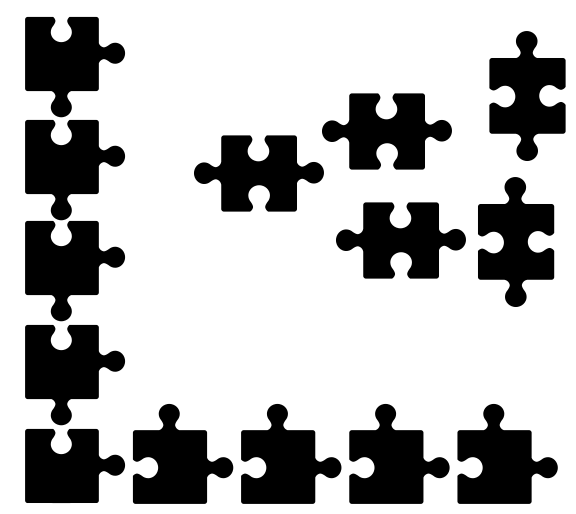

## Sort and build high contrast/color regions

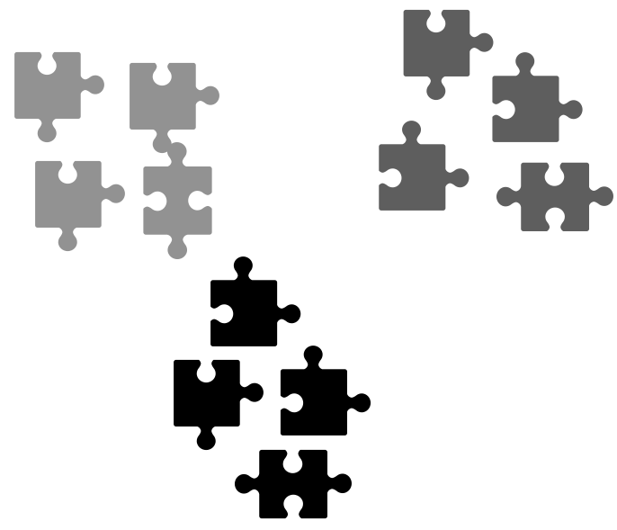

## Sort into knob-and-hole combinations

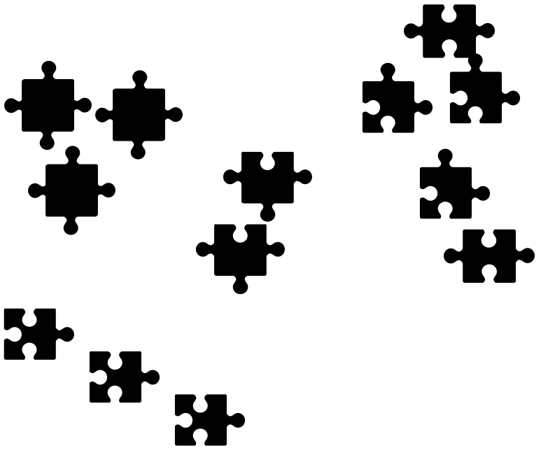

## How to measure puzzle strategy success/failure?

- time to completion
- average # tries to fitting piece
- proportion of first tries that fit

## Defining terms

*model selection* is “estimating the performance of different models in order to choose the best one”

- identify the best puzzle building strategy from among the candidates on a relative basis

*model assessment* is, “having chosen a final model, estimating its prediction error…on new data”

- measuring how good your chosen puzzle building strategy is

Hastie, Tibshirani, and Friedman (2009)

## Two main considerations

1. Using data honestly
2. Measuring error

## Using data honestly

## Notation

Each observation’s outcome \(Y\) (continuous or categorical) is to be predicted with function of auxiliary knowledge, i.e. covariates, from that observation \(X=x\), denoted as \(\hat Y(x)\)

Want \(\hat Y(x)\) to be close to \(Y\), but need to define what is meant by “close”

Use ‘mean squared prediction error’ (MSPE) for now: \((Y - \hat Y(x))^2\)

## Numeric example (binary outcome)

- Generate \(Y\) from logistic regression model: \(\Pr(Y = 1|X=x) = 1/(1+\exp(-\alpha+ x\beta))\)
- One observation consists of \(\{Y, x\}\)
- \(n = 100\) observations each in training and validation
- \(p = 20\) covariates, distributed as independent normal random variables
- \(p/2 = 10\) of coefficients equal to 0.25; remaining equal to 0
- Expected prevalence of about 0.6
- \(\hat Y(x)=\hat{\Pr}(Y=1|X=x) = 1/(1+\exp(-\hat\alpha+ x\hat\beta))\)

```r
set.seed(7201969);
#n = 200 observations; split into equal parts
n <- 200;
training_subset <- 1:round(n/2);
validation_subset <- (round(n/2)+1):n;
#p covariates
p <- 20;
#baseline prevalence approximately 0.6
alpha <- log(0.6/0.4);
#normally distributed covariates
x <- matrix(rnorm(n*p),
            nrow = n,
            dimnames = list(NULL,glue("x{1:p}")));
#half of covariates have odds ratios exp(0.25)
beta <- c(rep(0.25, floor(p/2)), numeric(ceiling(p/2)));
true_probs <- 1/(1+exp(-alpha - drop(x%*%beta)));
y <- rbinom(n, 1, true_probs);
all_data <- bind_cols(y = y, data.frame(x));
full_fmla <-
  glue("y~{glue_collapse(glue('x{1:p}'),sep='+')}") %>%
  as.formula();
```

Six strategies considered:

- True model (‘(truth)’; for benchmarking)
- Intercept only (‘null’; not considered for selection)
- All covariates (‘full’)
- Forward selection (‘forward’): start with the null model, incrementally add in covariates that seem to improve fit
- Forward selection with max of 1 variable / 20 observations in training data (‘forward_pruned’)
- Backward selection (‘backward’): start will the full model, incrementally subtract covariates that seem to harm fit

```r
full_model <- glm(full_fmla,
                 data = all_data,
                 subset = training_subset,
                 family = "binomial");
null_model <- glm(y ~ 1,
                 data = all_data,
                 subset = training_subset,
                 family = "binomial");

#forward selection (using MASS package)
forward_model <-
  stepAIC(null_model,
          scope = list(upper = full_fmla),
          direction = "forward",
          trace = F);

#pruned forward selection: max of 1 coefficient per 10 training observations
forward_pruned_model <-
  stepAIC(null_model,
          scope = list(upper = full_fmla),
          direction = "forward",
          steps = max(1, floor(training_subset / 20)),
          trace = F);

#backward selection
backward_model <-
  stepAIC(full_model,
          direction = "backward",
          trace = F);
```

## Selection

```r
tidy(full_model) %>%
  left_join(tibble(term = glue("x{1:floor(p/2)}"),
                   nonzero = 1)) %>%
  mutate(nonzero = replace_na(nonzero, 0)) %>%
  arrange(p.value);
```

```
## # A tibble: 21 × 6
##    term   estimate std.error statistic  p.value nonzero
##    <glue>    <dbl>     <dbl>     <dbl>    <dbl>   <dbl>
##  1 x8        1.59      0.440      3.62 0.000292       1
##  2 x11       1.09      0.386      2.81 0.00490        0
##  3 x1        0.908     0.382      2.38 0.0173         1
##  4 x6        0.754     0.330      2.29 0.0223         1
##  5 x4        0.696     0.327      2.13 0.0335         1
##  6 x13      -0.583     0.286     -2.04 0.0414         0
##  7 x18      -0.643     0.346     -1.86 0.0631         0
##  8 x5        0.486     0.325      1.49 0.135          1
##  9 x3        0.402     0.287      1.40 0.162          1
## 10 x14      -0.423     0.319     -1.33 0.185          0
## # ℹ 11 more rows
```

```r
tidy(forward_model) %>%
  left_join(tibble(term = glue("x{1:floor(p/2)}"),
                   nonzero = 1)) %>%
  mutate(nonzero = replace_na(nonzero, 0)) %>%
  arrange(p.value);
```

```
## # A tibble: 10 × 6
##    term        estimate std.error statistic  p.value nonzero
##    <glue>         <dbl>     <dbl>     <dbl>    <dbl>   <dbl>
##  1 x8            1.40       0.385     3.64  0.000276       1
##  2 x11           0.999      0.350     2.86  0.00429        0
##  3 x6            0.661      0.291     2.27  0.0231         1
##  4 x4            0.622      0.296     2.10  0.0354         1
##  5 x1            0.675      0.329     2.05  0.0404         1
##  6 x5            0.564      0.283     1.99  0.0466         1
##  7 x13          -0.480      0.248    -1.94  0.0527         0
##  8 x3            0.423      0.266     1.59  0.112          1
##  9 x18          -0.466      0.297    -1.57  0.117          0
## 10 (Intercept)   0.0440     0.331     0.133 0.894          0
```

```r
tidy(forward_pruned_model) %>%
  left_join(tibble(term = glue("x{1:floor(p/2)}"),
                   nonzero = 1)) %>%
  mutate(nonzero = replace_na(nonzero, 0)) %>%
  arrange(p.value);
```

```
## # A tibble: 6 × 6
##   term        estimate std.error statistic  p.value nonzero
##   <glue>         <dbl>     <dbl>     <dbl>    <dbl>   <dbl>
## 1 x8             1.28      0.352      3.63 0.000283       1
## 2 x11            0.816     0.298      2.74 0.00617        0
## 3 x6             0.504     0.251      2.01 0.0446         1
## 4 (Intercept)    0.489     0.257      1.90 0.0572         0
## 5 x5             0.472     0.259      1.82 0.0683         1
## 6 x4             0.369     0.253      1.46 0.145          1
```

```r
tidy(backward_model) %>%
  left_join(tibble(term = glue("x{1:floor(p/2)}"),
                   nonzero = 1)) %>%
  mutate(nonzero = replace_na(nonzero, 0)) %>%
  arrange(p.value);
```

```
## # A tibble: 10 × 6
##    term        estimate std.error statistic  p.value nonzero
##    <glue>         <dbl>     <dbl>     <dbl>    <dbl>   <dbl>
##  1 x8            1.40       0.385     3.64  0.000276       1
##  2 x11           0.999      0.350     2.86  0.00429        0
##  3 x6            0.661      0.291     2.27  0.0231         1
##  4 x4            0.622      0.296     2.10  0.0354         1
##  5 x1            0.675      0.329     2.05  0.0404         1
##  6 x5            0.564      0.283     1.99  0.0466         1
##  7 x13          -0.480      0.248    -1.94  0.0527         0
##  8 x3            0.423      0.266     1.59  0.112          1
##  9 x18          -0.466      0.297    -1.57  0.117          0
## 10 (Intercept)   0.0440     0.331     0.133 0.894          0
```

```r
predict_models <-
  list(null = null_model,
       full = full_model,
       forward = forward_model,
       forward_pruned = forward_pruned_model,
       backward = backward_model) %>%
  map_dfc(predict, newdata = all_data, type = 'resp') %>%
  mutate(true_probs = true_probs,
         y = y,
         training = row_number() %in% training_subset) %>%
  pivot_longer(c(true_probs, null:backward),
               names_to = "model_name") %>%
  mutate(model_name = factor(model_name) %>% fct_inorder())
```

## Training MSPEs

\(\dfrac{1}{100}\sum_{i=1}^{100} (Y_i - \hat Y(x_i))^2\)

```r
predict_models %>%
  filter(training) %>%
  group_by(model_name) %>%
  summarize(mspe = mean((y - value)^2))
```

```
## # A tibble: 6 × 2
##   model_name      mspe
##   <fct>          <dbl>
## 1 true_probs     0.198
## 2 null           0.230
## 3 full           0.143
## 4 forward        0.149
## 5 forward_pruned 0.171
## 6 backward       0.149
```

Full model has smallest MSPE in training subset

## Validation MSPEs

\(\dfrac{1}{100}\sum_{i=101}^{200} (Y_i - \hat Y(x_i))^2\)

```r
predict_models %>%
  filter(!training) %>%
  group_by(model_name) %>%
  summarize(mspe = mean((y - value)^2))
```

```
## # A tibble: 6 × 2
##   model_name      mspe
##   <fct>          <dbl>
## 1 true_probs     0.198
## 2 null           0.228
## 3 full           0.295
## 4 forward        0.282
## 5 forward_pruned 0.264
## 6 backward       0.282
```

Except for true and null models, all MSPEs increase dramatically

Pruned forward model has smallest MSPE in validation subset

- An aside: even though it has the smallest MSPE, is it still good in an absolute sense?

Assuming we report pruned forward model as *the* model, is this the MSPE we should expect in the future?

## Simulation study

- \(n = 100;100;100\) observations in training;validation;testing
- Same generating model as previously but repeat 2000 times
- In each simulated dataset, only three models are taken to the testing step: the true and null models (for benchmarking) and whichever other model has best validation MSPE

```r
source("simulator.R");
all_results <- run_sim(seed = 7201969);
```

```r
print(all_results, n = 18)
```

```
## # A tibble: 36,000 × 6
##      sim model_name     step        mspe row_number ranking
##    <int> <fct>          <fct>      <dbl>      <int>   <dbl>
##  1     1 (truth)        training   0.276          1     Inf
##  2     1 (truth)        validation 0.185          2     Inf
##  3     1 (truth)        testing    0.179          3     Inf
##  4     1 null           training   0.248          4     Inf
##  5     1 null           validation 0.279          5     Inf
##  6     1 null           testing    0.264          6     Inf
##  7     1 full           training   0.220          7       4
##  8     1 full           validation 0.283          8       4
##  9     1 full           testing    0.227          9       4
## 10     1 forward        training   0.248         10       2
## 11     1 forward        validation 0.279         11       2
## 12     1 forward        testing    0.264         12       2
## 13     1 forward_pruned training   0.248         13       2
## 14     1 forward_pruned validation 0.279         14       2
## 15     1 forward_pruned testing    0.264         15       2
## 16     1 backward       training   0.248         16       2
## 17     1 backward       validation 0.279         17       2
## 18     1 backward       testing    0.264         18       2
## # ℹ 35,982 more rows
```

```r
observed_results <-
  all_results %>%
  group_by(sim) %>%
  #keep from the test step only the method we would have selected
  filter(model_name %in% c("(truth)","null") | step != "testing" | ranking == min(ranking)) %>%
  ungroup();
```

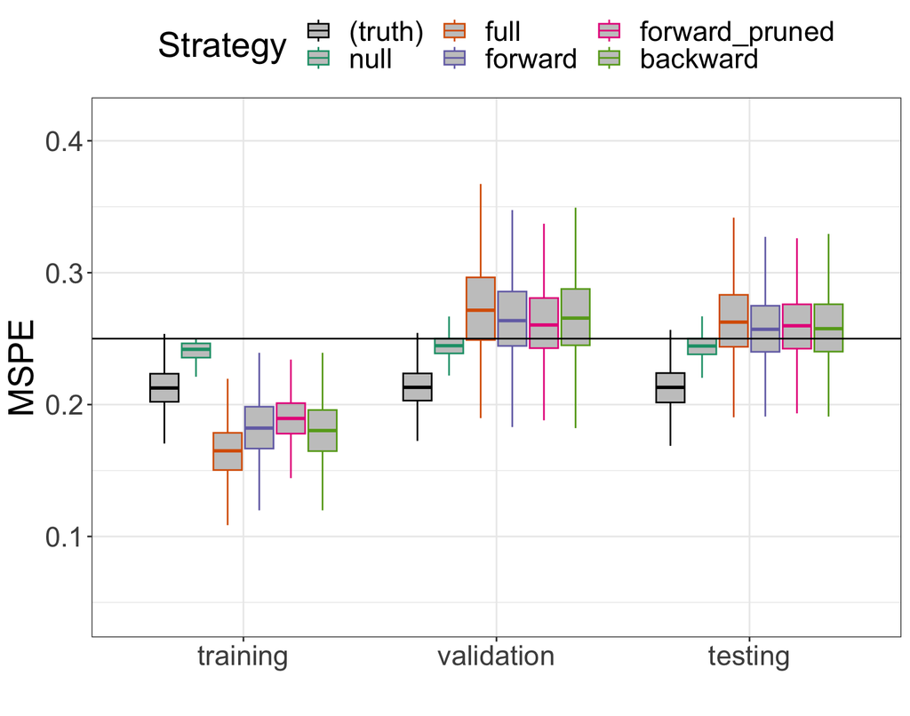

```r
model_colors = c("black",brewer.pal(5, "Dark2"));
ggplot(observed_results) +
  geom_boxplot(aes(x = step,
                   y = mspe,
                   color = model_name),
               fill = "#AAAAAAAA",
               outlier.shape = NA,
               varwidth = FALSE) +
  geom_hline(yintercept = 0.25) +
  scale_color_manual(values = model_colors) +
  labs(x = "", y = "MSPE",  color = "Strategy") +
  theme(text = element_text(size = 22),
        legend.position = "top");
```

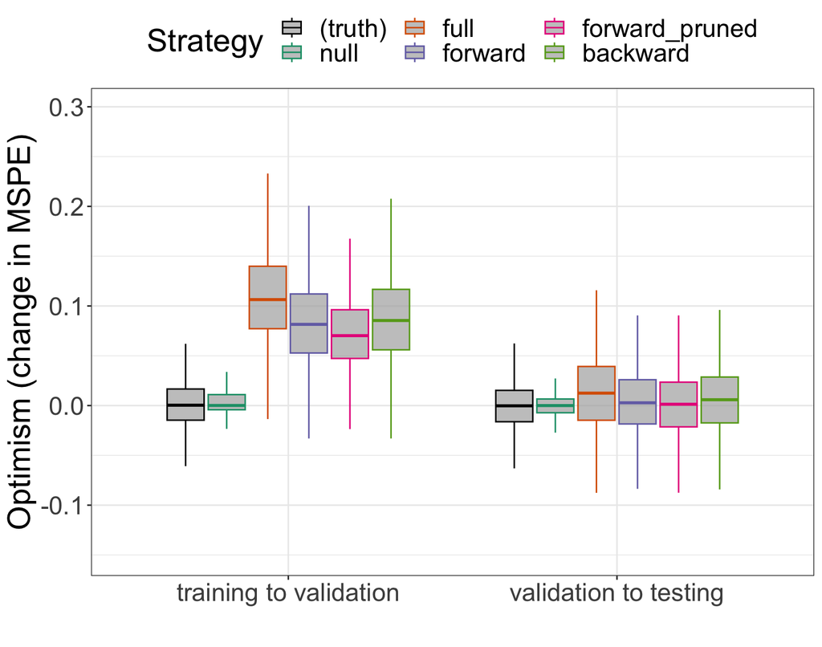

```r
change_in_optimism <-
  observed_results %>%
  dplyr::select(-row_number) %>%
  pivot_wider(names_from = step, values_from = mspe) %>%
  mutate(validation_minus_training = validation - training,
         testing_minus_validation = testing - validation) %>%
  dplyr::select(-training, -validation, -testing) %>%
  pivot_longer(cols = contains("minus"), names_to = "delta", values_to = "value") %>%
  group_by(sim) %>%
  filter(model_name %in% c("(truth)","null") | delta == "validation_minus_training" | ranking == min(ranking)) %>%
  ungroup() %>%
  mutate(delta = factor(delta,
                        levels = c("validation_minus_training",
                                   "testing_minus_validation"),
                        labels = c("training to validation",
                                   "validation to testing")));
ggplot(change_in_optimism) +
  geom_boxplot(aes(x = delta,
                   y = value,
                   color = model_name),
               fill = "#AAAAAAAA",
               outlier.shape = NA,
               varwidth = FALSE) +
  scale_color_manual(values = model_colors) +
  labs(x = "",
       y = "Optimism (change in MSPE)",
       color = "Strategy") +
  theme(text = element_text(size = 22),
        legend.position = "top");
```

Model *selection*, conducted properly, adjusts for optimism in training

Model *assessment*, conducted properly, adjusts for regression to the mean; potential for optimism increases with variability of method

## Measuring error

When \(Y\) is binary, there are several ways of thinking about ‘error’

1. overall prediction error
2. calibration
3. discrimation

Steyerberg et al. (2010)

Model assessment can be based on any sensible, quantifiable error function

## Overall prediction error

“How close are the actual outcomes to the predicted outcomes?”

\(\hat Y(x)=\hat{\Pr}(Y=1|X=x)\)

*MSPE* or *Brier score*: \(=(Y - \hat Y(x))^2\)

*Absolute*: \(=|Y - \hat Y(x)|\)

*0-1*: \((1-Y)\times 1_{[ \hat Y(x)\geq0.5]} + Y\times 1_{[ \hat Y(x)<0.5]}\)

*Deviance*: \(-2(1-Y)\log[1- \hat Y(x)] -2Y\log \hat Y(x)\)

## Error functions against \(\hat Y(x)\) when \(Y=1\)

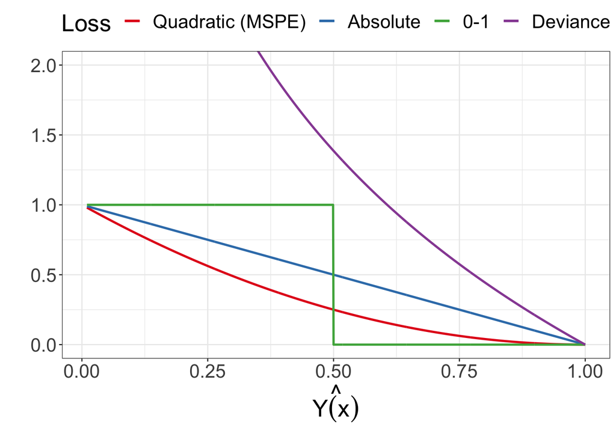

```r
prob_seq <- seq(0.01, 1, by = 0.001);#
ggplot() +
  geom_path(aes(x = prob_seq, y = (1-prob_seq)^2, color = "1Quadratic"), size = 1) +
  geom_path(aes(x = prob_seq, y = abs(1-prob_seq), color = "2Absolute"), size = 1) +
  geom_path(aes(x = prob_seq, y = 1*(prob_seq < 0.5), color = "30-1"), size = 1) +
  geom_path(aes(x = prob_seq, y = -2 * log(prob_seq), color = "4Deviance"), size = 1) +
  coord_cartesian(ylim = c(0, 2)) +
  scale_color_manual(labels = c("Quadratic (MSPE)", "Absolute", "0-1", "Deviance"),
                     values = c("#E41A1C","#377EB8","#4DAF4A","#984EA3")) +
  labs(x = expression(hat(Y(x))),
       y = "",
       color = "Loss") +
  theme(text = element_text(size = 22),
        legend.position = "top");
```

## Calibration

“Among observations with predicted prevalence of X%, is the true prevalence close to X%?”

- overall error functions capture elements of calibration
- Hosmer-Lemeshow test: group observations based upon \(\hat Y(x)\), compare \(\sum_i \hat Y(x_i)\) to \(\sum_i Y_i\)

## Discrimination

“Did the observations in which the outcome occured have a higher predicted risk than the observations in which the outcome did not occur?”

*Sensitivity*: probability of predicting \(\hat Y(x)=1\) given that, in truth, \(Y(x)=1\)

- it is not the probability that \(Y(x)=1\) given that we’ve predicted \(\hat Y(x)=1\)

*Specificity*: probability of predicting \(\hat Y(x)=0\) given that, in truth, \(Y(x)=0\)

- same caution as above

*Receiver operator characteristic (ROC) curve*: plot of \(\hat{\mathrm{sens}}(t)\) versus \(1-\hat{\mathrm{spec}}(t)\) for \(t\in[0,1]\), where

- \(\hat{\mathrm{sens}}(t) = \dfrac{\sum_{i:Y_i=1}1_{[\hat Y(x) > t]}}{\sum_{i:Y_i=1} 1}\) and
- \(\hat{\mathrm{spec}}(t) = \dfrac{\sum_{i:Y_i=0}1_{[\hat Y(x) \leq t]}}{\sum_{i:Y_i=0} 1}\)

*concordance (\(c\)) index* : \(\dfrac{\sum_{i,j:Y_i=0,Y_j=1} 1_{[\hat Y(x_i) < \hat Y(x_j)]} + 0.5\times 1_{[\hat Y(x_i) = \hat Y(x_j)]}}{ \sum_{i,j:Y_i=0,Y_j=1} 1}\)

```r
# use pROC package
true_training_roc <-
  predict_models %>%
  filter(training, model_name == "true_probs") %>%
  roc(response = y, predictor = value)

true_validation_roc <-
  predict_models %>%
  filter(!training, model_name == "true_probs") %>%
  roc(response = y, predictor = value)

full_training_roc <-
  predict_models %>%
  filter(training, model_name == "full") %>%
  roc(response = y, predictor = value)

full_validation_roc <-
  predict_models %>%
  filter(!training, model_name == "full") %>%
  roc(response = y, predictor = value)

forward_pruned_training_roc <-
  predict_models %>%
  filter(training, model_name == "forward_pruned") %>%
  roc(response = y, predictor = value)

forward_pruned_validation_roc <-
predict_models %>%
  filter(!training, model_name == "forward_pruned") %>%
  roc(response = y, predictor = value)

roc_data <-
    bind_rows(tibble(model = "(truth)",
                   step = "training",
                   sens = true_training_roc$sensitivities,
                   spec = true_training_roc$specificities,
                   thresh = true_training_roc$thresholds),
            tibble(model = "(truth)",
                   step = "validation",
                   sens = true_validation_roc$sensitivities,
                   spec = true_validation_roc$specificities,
                   thresh = true_validation_roc$thresholds),
            tibble(model = "full",
                   step = "training",
                   sens = full_training_roc$sensitivities,
                   spec = full_training_roc$specificities,
                   thresh = full_training_roc$thresholds),
            tibble(model = "full",
                   step = "validation",
                   sens = full_validation_roc$sensitivities,
                   spec = full_validation_roc$specificities,
                   thresh = full_validation_roc$thresholds),
            tibble(model = "forward_pruned",
                   step = "training",
                   sens = forward_pruned_training_roc$sensitivities,
                   spec = forward_pruned_training_roc$specificities,
                   thresh = forward_pruned_training_roc$thresholds),
            tibble(model = "forward_pruned",
                   step = "validation",
                   sens = forward_pruned_validation_roc$sensitivities,
                   spec = forward_pruned_validation_roc$specificities,
                   thresh = forward_pruned_validation_roc$thresholds)) %>%
  mutate(model = factor(model, levels = c("(truth)","full", "forward_pruned"))) %>%
  group_by(model, step) %>%
  mutate(annotate = ifelse(abs(0.5 - thresh) == min(abs(0.5 - thresh)), TRUE, FALSE)) %>%
  ungroup() %>%
  arrange(model, step, desc(spec), sens);
```

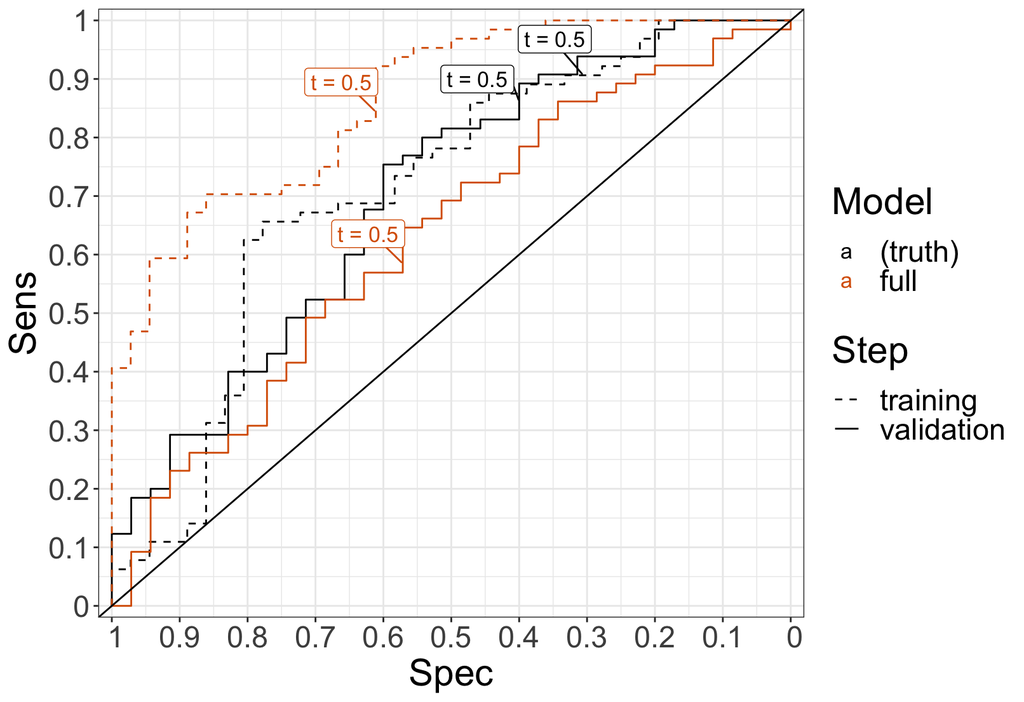

```r
roc_plot <-
  ggplot(filter(roc_data, model != "forward_pruned"),
         aes(x = 1 - spec,
             y = sens,
             color = model,
             linetype = step)) +
  geom_path() +
  geom_abline(intercept = 0, slope = 1) +
  geom_label_repel(data = filter(roc_data, annotate, model != "forward_pruned"),
                   aes(label = paste0("t = ", formatC(thresh, format = "f", digits = 1))),
                   nudge_x = -0.051,
                   nudge_y = 0.051,
                   size = cex_scale) +
  scale_x_continuous(name = "Spec",
                     breaks = seq(0, 1, length = 11),
                     labels = formatC(seq(1, 0, length = 11), format = "g", digits = 1),
                     expand = expand_scale(add = 0.02)) +
  scale_y_continuous(name = "Sens",
                     breaks = seq(0, 1, length = 11),
                     labels = formatC(seq(0, 1, length = 11), format = "g", digits = 1),
                     expand = expand_scale(add = 0.02)) +
  scale_linetype_manual(name = "Step",
                        values = c("dashed", "solid")) +
  scale_color_manual(name = "Model",
                     values = model_colors[c(1,3)]) +
  theme(text = element_text(size = 22));
roc_plot;
```

## Interpreting ROC curve

For the full model:

- For fixed specificity of 0.8, can plausibly expect sensitivity of about 0.3
- If we classify based upon cutoff of \(\hat Y(x) > 0.5\) versus \(\hat Y(x) \leq 0.5\),we would expect sensitivity ~0.6 and specificity ~0.57
- Achieving high sensitivity is difficult without sacrificing specificity

What does least ideal ROC curve look like?

## Area under ROC curve (AUC or AUROC)

ROC curves are interesting if range of cutoffs are of interest

However, it has been shown that the *area under the ROC curve* is, in the case of logistic regression, the \(c\)-index:

\[\dfrac{\sum_{i,j:Y_i=0,Y_j=1} 1_{[\hat Y(x_i) < \hat Y(x_j)]}}{ \sum_{i,j:Y_i=0,Y_j=1} 1}\]

This estimates the probability of correctly ordering the risk of a randomly selected outcome and randomly selected non-outcome.

## AUC

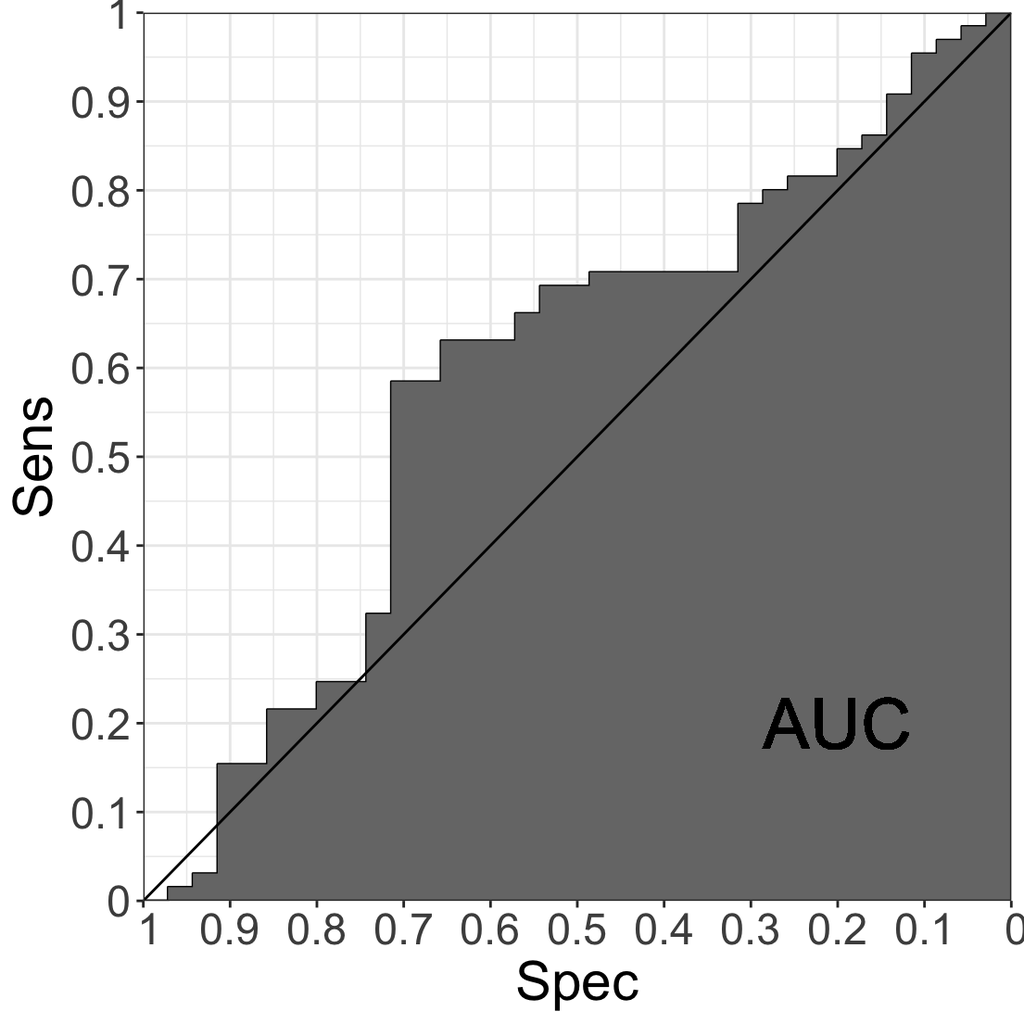

## AOC = 1 - AUC

[figure not shown]

## Higher AUC is better

AUCs for ‘(true)’ and ‘full’ in training step:

```r
true_training_roc$auc;
```

```
## Area under the curve: 0.711
```

```r
full_training_roc$auc;
```

```
## Area under the curve: 0.862
```

AUCs for ‘(true)’ and ‘full’ in validation step:

```r
true_validation_roc$auc;
```

```
## Area under the curve: 0.7
```

```r
full_validation_roc$auc;
```

```
## Area under the curve: 0.629
```

What is AUC under the intercept-only (null) model?

## Summary thoughts on model assessment

Potential for optimism increases with inherent variability of model building method

## Summary thoughts on model assessment

Be specific when saying the model was ‘validated’, and don’t assume others mean what they think they mean:

- Does this refer to validation (model selection) or testing (model assessment)?
- How was validation measured?
- If cross-validation was involved, was it done properly?
- Was the set of models considered sensible?
- What population did validation and testing occur in?

## Summary thoughts on model assessment

The effective region for improvement (difference between null and true models) is often narrow, especially in binary outcome models

## References

Hastie, T, R Tibshirani, and J Friedman. 2009. *The Elements of Statistical Learning: Data Mining, Inference, and Prediction*. 2nd ed. New York, NY: Springer.

Steyerberg, Ewout W, Andrew J Vickers, Nancy R Cook, Thomas Gerds, Mithat Gonen, Nancy Obuchowski, Michael J Pencina, and Michael W Kattan. 2010. “Assessing the Performance of Prediction Models: A Framework for Some Traditional and Novel Measures.” *Epidemiology (Cambridge, Mass.)* 21 (1): 128.